# JSON examples and exercise

- get familiar with packages for dealing with JSON
- study examples with JSON strings and files
- work on exercise to be completed and submitted
- reference: http://pandas.pydata.org/pandas-docs/stable/io.html#io-json-reader
- data source: http://jsonstudio.com/resources/

```python
import pandas as pd
```

## imports for Python, Pandas

```python
import json
from pandas.io.json import json_normalize
```

## JSON example, with string

- demonstrates creation of normalized dataframes (tables) from nested json string
- source: http://pandas.pydata.org/pandas-docs/stable/io.html#normalization

```python
# define json string
data = [{'state': 'Florida',
         'shortname': 'FL',
         'info': {'governor': 'Rick Scott'},
         'counties': [{'name': 'Dade', 'population': 12345},
                      {'name': 'Broward', 'population': 40000},
                      {'name': 'Palm Beach', 'population': 60000}]},
        {'state': 'Ohio',
         'shortname': 'OH',
         'info': {'governor': 'John Kasich'},
         'counties': [{'name': 'Summit', 'population': 1234},
                      {'name': 'Cuyahoga', 'population': 1337}]}]
```

```python
# use normalization to create tables from nested element
json_normalize(data, 'counties')
```

|  | name | population |
| --- | --- | --- |
| 0 | Dade | 12345 |
| 1 | Broward | 40000 |
| 2 | Palm Beach | 60000 |
| 3 | Summit | 1234 |
| 4 | Cuyahoga | 1337 |

```python
# further populate tables created from nested element
json_normalize(data, 'counties', ['state', 'shortname', ['info', 'governor']])
```

|  | name | population | state | shortname | info.governor |
| --- | --- | --- | --- | --- | --- |
| 0 | Dade | 12345 | Florida | FL | Rick Scott |
| 1 | Broward | 40000 | Florida | FL | Rick Scott |
| 2 | Palm Beach | 60000 | Florida | FL | Rick Scott |
| 3 | Summit | 1234 | Ohio | OH | John Kasich |
| 4 | Cuyahoga | 1337 | Ohio | OH | John Kasich |

## JSON example, with file

- demonstrates reading in a json file as a string and as a table
- uses small sample file containing data about projects funded by the World Bank
- data source: http://jsonstudio.com/resources/

```python
# load json as string
json.load((open('data/world_bank_projects_less.json')))
```

```
[{'_id': {'$oid': '52b213b38594d8a2be17c780'},
  'approvalfy': 1999,
  'board_approval_month': 'November',
  'boardapprovaldate': '2013-11-12T00:00:00Z',
  'borrower': 'FEDERAL DEMOCRATIC REPUBLIC OF ETHIOPIA',
  'closingdate': '2018-07-07T00:00:00Z',
  'country_namecode': 'Federal Democratic Republic of Ethiopia!$!ET',
  'countrycode': 'ET',
  'countryname': 'Federal Democratic Republic of Ethiopia',
  'countryshortname': 'Ethiopia',
  'docty': 'Project Information Document,Indigenous Peoples Plan,Project Information Document',
  'envassesmentcategorycode': 'C',
  'grantamt': 0,
  'ibrdcommamt': 0,
  'id': 'P129828',
  'idacommamt': 130000000,
  'impagency': 'MINISTRY OF EDUCATION',
  'lendinginstr': 'Investment Project Financing',
  'lendinginstrtype': 'IN',
  'lendprojectcost': 550000000,
  'majorsector_percent': [{'Name': 'Education', 'Percent': 46},
   {'Name': 'Education', 'Percent': 26},
   {'Name': 'Public Administration, Law, and Justice', 'Percent': 16},
   {'Name': 'Education', 'Percent': 12}],
  'mjsector_namecode': [{'name': 'Education', 'code': 'EX'},
   {'name': 'Education', 'code': 'EX'},
   {'name': 'Public Administration, Law, and Justice', 'code': 'BX'},
   {'name': 'Education', 'code': 'EX'}],
  'mjtheme': ['Human development'],
  'mjtheme_namecode': [{'name': 'Human development', 'code': '8'},
   {'name': '', 'code': '11'}],
  'mjthemecode': '8,11',
  'prodline': 'PE',
  'prodlinetext': 'IBRD/IDA',
  'productlinetype': 'L',
  'project_abstract': {'cdata': 'The development objective of the Second Phase of General Education Quality Improvement Project for Ethiopia is to improve learning conditions in primary and secondary schools and strengthen institutions at different levels of educational administration. The project h…
  'project_name': 'Ethiopia General Education Quality Improvement Project II',
  'projectdocs': [{'DocTypeDesc': 'Project Information Document (PID),  Vol.',
    'DocType': 'PID',
    'EntityID': '090224b081e545fb_1_0',
```

[output cut: 108 more lines]

```
  'sector2': {'Name': 'General public administration sector', 'Percent': 30},
  'sector_namecode': [{'name': 'Public administration- Other social services',
    'code': 'BS'},
   {'name': 'General public administration sector', 'code': 'BZ'}],
  'sectorcode': 'BZ,BS',
  'source': 'IBRD',
  'status': 'Active',
  'supplementprojectflg': 'N',
  'theme1': {'Name': 'Other economic management', 'Percent': 30},
  'theme_namecode': [{'name': 'Other economic management', 'code': '24'},
   {'name': 'Social safety nets', 'code': '54'}],
  'themecode': '54,24',
  'totalamt': 0,
  'totalcommamt': 4700000,
  'url': 'http://www.worldbank.org/projects/P144674?lang=en'}]
```

```python
# load as Pandas dataframe
sample_json_df = pd.read_json('data/world_bank_projects_less.json')
sample_json_df
```

|  | _id | approvalfy | board_approval_month | boardapprovaldate | borrower | closingdate | country_namecode | countrycode | countryname | countryshortname | ... | sectorcode | source | status | supplementprojectflg | theme1 | theme_namecode | themecode | totalamt | totalcommamt | url |
| --- | --- | --- | --- | --- | --- | --- | --- | --- | --- | --- | --- | --- | --- | --- | --- | --- | --- | --- | --- | --- | --- |
| 0 | {'$oid': '52b213b38594d8a2be17c780'} | 1999 | November | 2013-11-12T00:00:00Z | FEDERAL DEMOCRATIC REPUBLIC OF ETHIOPIA | 2018-07-07T00:00:00Z | Federal Democratic Republic of Ethiopia!$!ET | ET | Federal Democratic Republic of Ethiopia | Ethiopia | ... | ET,BS,ES,EP | IBRD | Active | N | {'Name': 'Education for all', 'Percent': 100} | [{'name': 'Education for all', 'code': '65'}] | 65 | 130000000 | 130000000 | http://www.worldbank.org/projects/P129828/ethi... |
| 1 | {'$oid': '52b213b38594d8a2be17c781'} | 2015 | November | 2013-11-04T00:00:00Z | GOVERNMENT OF TUNISIA | NaN | Republic of Tunisia!$!TN | TN | Republic of Tunisia | Tunisia | ... | BZ,BS | IBRD | Active | N | {'Name': 'Other economic management', 'Percent... | [{'name': 'Other economic management', 'code':... | 54,24 | 0 | 4700000 | http://www.worldbank.org/projects/P144674?lang=en |

2 rows × 50 columns

## JSON exercise

Using data in file 'data/world_bank_projects.json' and the techniques demonstrated above,

1. Find the 10 countries with most projects
2. Find the top 10 major project themes (using column 'mjtheme_namecode')
3. In 2. above you will notice that some entries have only the code and the name is missing. Create a dataframe with the missing names filled in.

```python
# Creating a new dataframe with world_bank_projects.json file

wb_df = pd.read_json('data/world_bank_projects.json')
```

```python
# View the dataframe

wb_df.head(10)
```

|  | _id | approvalfy | board_approval_month | boardapprovaldate | borrower | closingdate | country_namecode | countrycode | countryname | countryshortname | ... | sectorcode | source | status | supplementprojectflg | theme1 | theme_namecode | themecode | totalamt | totalcommamt | url |
| --- | --- | --- | --- | --- | --- | --- | --- | --- | --- | --- | --- | --- | --- | --- | --- | --- | --- | --- | --- | --- | --- |
| 0 | {'$oid': '52b213b38594d8a2be17c780'} | 1999 | November | 2013-11-12T00:00:00Z | FEDERAL DEMOCRATIC REPUBLIC OF ETHIOPIA | 2018-07-07T00:00:00Z | Federal Democratic Republic of Ethiopia!$!ET | ET | Federal Democratic Republic of Ethiopia | Ethiopia | ... | ET,BS,ES,EP | IBRD | Active | N | {'Percent': 100, 'Name': 'Education for all'} | [{'code': '65', 'name': 'Education for all'}] | 65 | 130000000 | 130000000 | http://www.worldbank.org/projects/P129828/ethi... |
| 1 | {'$oid': '52b213b38594d8a2be17c781'} | 2015 | November | 2013-11-04T00:00:00Z | GOVERNMENT OF TUNISIA | NaN | Republic of Tunisia!$!TN | TN | Republic of Tunisia | Tunisia | ... | BZ,BS | IBRD | Active | N | {'Percent': 30, 'Name': 'Other economic manage... | [{'code': '24', 'name': 'Other economic manage... | 54,24 | 0 | 4700000 | http://www.worldbank.org/projects/P144674?lang=en |
| 2 | {'$oid': '52b213b38594d8a2be17c782'} | 2014 | November | 2013-11-01T00:00:00Z | MINISTRY OF FINANCE AND ECONOMIC DEVEL | NaN | Tuvalu!$!TV | TV | Tuvalu | Tuvalu | ... | TI | IBRD | Active | Y | {'Percent': 46, 'Name': 'Regional integration'} | [{'code': '47', 'name': 'Regional integration'... | 52,81,25,47 | 6060000 | 6060000 | http://www.worldbank.org/projects/P145310?lang=en |
| 3 | {'$oid': '52b213b38594d8a2be17c783'} | 2014 | October | 2013-10-31T00:00:00Z | MIN. OF PLANNING AND INT'L COOPERATION | NaN | Republic of Yemen!$!RY | RY | Republic of Yemen | Yemen, Republic of | ... | JB | IBRD | Active | N | {'Percent': 50, 'Name': 'Participation and civ... | [{'code': '57', 'name': 'Participation and civ... | 59,57 | 0 | 1500000 | http://www.worldbank.org/projects/P144665?lang=en |
| 4 | {'$oid': '52b213b38594d8a2be17c784'} | 2014 | October | 2013-10-31T00:00:00Z | MINISTRY OF FINANCE | 2019-04-30T00:00:00Z | Kingdom of Lesotho!$!LS | LS | Kingdom of Lesotho | Lesotho | ... | FH,YW,YZ | IBRD | Active | N | {'Percent': 30, 'Name': 'Export development an... | [{'code': '45', 'name': 'Export development an... | 41,45 | 13100000 | 13100000 | http://www.worldbank.org/projects/P144933/seco... |
| 5 | {'$oid': '52b213b38594d8a2be17c785'} | 2014 | October | 2013-10-31T00:00:00Z | REPUBLIC OF KENYA | NaN | Republic of Kenya!$!KE | KE | Republic of Kenya | Kenya | ... | JB | IBRD | Active | Y | {'Percent': 100, 'Name': 'Social safety nets'} | [{'code': '54', 'name': 'Social safety nets'}] | 54 | 10000000 | 10000000 | http://www.worldbank.org/projects/P146161?lang=en |
| 6 | {'$oid': '52b213b38594d8a2be17c786'} | 2014 | October | 2013-10-29T00:00:00Z | GOVERNMENT OF INDIA | 2019-06-30T00:00:00Z | Republic of India!$!IN | IN | Republic of India | India | ... | TI | IBRD | Active | N | {'Percent': 20, 'Name': 'Administrative and ci... | [{'code': '25', 'name': 'Administrative and ci... | 39,25 | 500000000 | 500000000 | http://www.worldbank.org/projects/P121185/firs... |
| 7 | {'$oid': '52b213b38594d8a2be17c787'} | 2014 | October | 2013-10-29T00:00:00Z | PEOPLE'S REPUBLIC OF CHINA | NaN | People's Republic of China!$!CN | CN | People's Republic of China | China | ... | LR | IBRD | Active | N | {'Percent': 100, 'Name': 'Climate change'} | [{'code': '81', 'name': 'Climate change'}] | 81 | 0 | 27280000 | http://www.worldbank.org/projects/P127033/chin... |
| 8 | {'$oid': '52b213b38594d8a2be17c788'} | 2014 | October | 2013-10-29T00:00:00Z | THE GOVERNMENT OF INDIA | 2018-12-31T00:00:00Z | Republic of India!$!IN | IN | Republic of India | India | ... | TI | IBRD | Active | N | {'Percent': 87, 'Name': 'Other rural developme... | [{'code': '79', 'name': 'Other rural developme... | 79 | 160000000 | 160000000 | http://www.worldbank.org/projects/P130164/raja... |
| 9 | {'$oid': '52b213b38594d8a2be17c789'} | 2014 | October | 2013-10-29T00:00:00Z | THE KINGDOM OF MOROCCO | 2014-12-31T00:00:00Z | Kingdom of Morocco!$!MA | MA | Kingdom of Morocco | Morocco | ... | BM,BC,BZ | IBRD | Active | N | {'Percent': 33, 'Name': 'Other accountability/... | [{'code': '29', 'name': 'Other accountability/... | 27,30,29 | 200000000 | 200000000 | http://www.worldbank.org/projects/P130903?lang=en |

10 rows × 50 columns

```python
# Checking the dimension of the data

wb_df.shape
```

```
(500, 50)
```

#### 1. Top 10 countries with the highest projects

```python
# 1. Top 10 Countries as per projects count

wb_df.columns
```

```
Index(['_id', 'approvalfy', 'board_approval_month', 'boardapprovaldate',
       'borrower', 'closingdate', 'country_namecode', 'countrycode',
       'countryname', 'countryshortname', 'docty', 'envassesmentcategorycode',
       'grantamt', 'ibrdcommamt', 'id', 'idacommamt', 'impagency',
       'lendinginstr', 'lendinginstrtype', 'lendprojectcost',
       'majorsector_percent', 'mjsector_namecode', 'mjtheme',
       'mjtheme_namecode', 'mjthemecode', 'prodline', 'prodlinetext',
       'productlinetype', 'project_abstract', 'project_name', 'projectdocs',
       'projectfinancialtype', 'projectstatusdisplay', 'regionname', 'sector',
       'sector1', 'sector2', 'sector3', 'sector4', 'sector_namecode',
       'sectorcode', 'source', 'status', 'supplementprojectflg', 'theme1',
       'theme_namecode', 'themecode', 'totalamt', 'totalcommamt', 'url'],
      dtype='object')
```

```python
wb_df[['project_name', 'countryshortname']].head(10)
```

|  | project_name | countryshortname |
| --- | --- | --- |
| 0 | Ethiopia General Education Quality Improvement... | Ethiopia |
| 1 | TN: DTF Social Protection Reforms Support | Tunisia |
| 2 | Tuvalu Aviation Investment Project - Additiona... | Tuvalu |
| 3 | Gov't and Civil Society Organization Partnership | Yemen, Republic of |
| 4 | Second Private Sector Competitiveness and Econ... | Lesotho |
| 5 | Additional Financing for Cash Transfers for Or... | Kenya |
| 6 | National Highways Interconnectivity Improvemen... | India |
| 7 | China Renewable Energy Scale-Up Program Phase II | China |
| 8 | Rajasthan Road Sector Modernization Project | India |
| 9 | MA Accountability and Transparency DPL | Morocco |

```python
# The top 10 countries with the highest number of projects are:

wb_df.countryshortname.value_counts().nlargest(10)
```

```
Indonesia             19
China                 19
Vietnam               17
India                 16
Yemen, Republic of    13
Bangladesh            12
Morocco               12
Nepal                 12
Africa                11
Mozambique            11
Name: countryshortname, dtype: int64
```

An interesting observation here is that it lists Africa as a country name when it is, in fact, a continent. Let us skip Africa and choose the next country that appears in the list for our final answer

```python
# Choosing top 10 COUNTRIES from the following list:

wb_df.countryshortname.value_counts().nlargest(11)
```

```
Indonesia             19
China                 19
Vietnam               17
India                 16
Yemen, Republic of    13
Bangladesh            12
Morocco               12
Nepal                 12
Africa                11
Mozambique            11
Pakistan               9
Name: countryshortname, dtype: int64
```

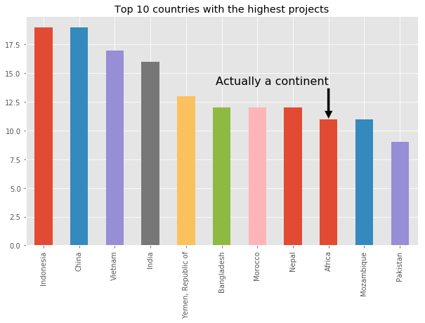

```python
# Import new library for plotting

import matplotlib.pyplot as plt

%matplotlib inline

# Setting style for R's popular ggplot library

plt.style.use('ggplot')

# Setting a larger figure size for the graph

plt.figure(figsize = (10, 6))

# Plotting a bar graph

wb_df.countryshortname.value_counts().nlargest(11).plot(kind = 'bar')
plt.title('Top 10 countries with the highest projects')
plt.annotate('Actually a continent', xy = (8, 11), xytext = (8, 14),
             arrowprops = dict(facecolor = 'black'),
             ha = 'right', size = 16);
```

#### 2. Top 10 major project themes

```python
# 2. Top 10 major project themes

wb_df.mjtheme_namecode.head(10)
```

```
0    [{'code': '8', 'name': 'Human development'}, {...
1    [{'code': '1', 'name': 'Economic management'},...
2    [{'code': '5', 'name': 'Trade and integration'...
3    [{'code': '7', 'name': 'Social dev/gender/incl...
4    [{'code': '5', 'name': 'Trade and integration'...
5    [{'code': '6', 'name': 'Social protection and ...
6    [{'code': '2', 'name': 'Public sector governan...
7    [{'code': '11', 'name': 'Environment and natur...
8    [{'code': '10', 'name': 'Rural development'}, ...
9    [{'code': '2', 'name': 'Public sector governan...
Name: mjtheme_namecode, dtype: object
```

```python
# Let's create a new df for this

json_file = json.load(open('data/world_bank_projects.json'))

wb_df2 = json_normalize(json_file, 'mjtheme_namecode')

wb_df2.head(10)
```

|  | code | name |
| --- | --- | --- |
| 0 | 8 | Human development |
| 1 | 11 |  |
| 2 | 1 | Economic management |
| 3 | 6 | Social protection and risk management |
| 4 | 5 | Trade and integration |
| 5 | 2 | Public sector governance |
| 6 | 11 | Environment and natural resources management |
| 7 | 6 | Social protection and risk management |
| 8 | 7 | Social dev/gender/inclusion |
| 9 | 7 | Social dev/gender/inclusion |

```python
# Top 10 project themes

wb_df2.name.value_counts().nlargest(10)
```

```
Environment and natural resources management    223
Rural development                               202
Human development                               197
Public sector governance                        184
Social protection and risk management           158
Financial and private sector development        130
                                                122
Social dev/gender/inclusion                     119
Trade and integration                            72
Urban development                                47
Name: name, dtype: int64
```

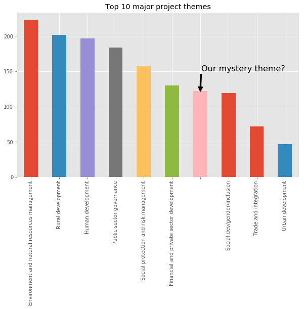

```python
# Plotting the bar graph for top 10 major themes

plt.figure(figsize = (10, 6))

wb_df2.name.value_counts().nlargest(10).plot(kind = 'bar')
plt.title('Top 10 major project themes')
plt.annotate('Our mystery theme?', xy = (6, 120),
             xytext = (9, 150),
             arrowprops = dict(facecolor = 'black'),
             ha = 'right', size = 16);
```

The top 10 project themes are:

1. Environment and natural resources management
2. Rural development
3. Human development
4. Public sector governance
5. Social protection and risk management
6. Financial and private sector development
7. < blank >
8. Social dev/gender/inclusion
9. Trade and integration
10. Urban development

The 7th largest project theme seems to be missing. Let us address this in the next task.

#### 3. Creating a dataframe with the missing names filled in

As we might have observed by now, a lot of codes are not mapped with the names of the project which is what has created a separate BLANK category. Our objective here would be to ensure all the codes are mapped accurately with the project name.

```python
# Let us build a dictionary which has all the code-name mappings

dict_map = {}
```

```python
# Iterating through the entire dataframe

for i in wb_df2.itertuples():
    if i[2] != '':
        dict_map[i[1]] = i[2]
```

```python
# let's see how mapped dictionary now

dict_map
```

```
{'8': 'Human development',
 '1': 'Economic management',
 '6': 'Social protection and risk management',
 '5': 'Trade and integration',
 '2': 'Public sector governance',
 '11': 'Environment and natural resources management',
 '7': 'Social dev/gender/inclusion',
 '4': 'Financial and private sector development',
 '10': 'Rural development',
 '9': 'Urban development',
 '3': 'Rule of law'}
```

```python
# Now we iterate over the named tuples again
# We check for rows where name is blank
# Then we replace it with the corresponding name from our dict_map using .at method

for i in wb_df2.itertuples():
    if i[2] == '':
        wb_df2.set_value(i[0], 'name', dict_map[i[1]])
```

```python
# Result:

wb_df2.name.value_counts()
```

```
Environment and natural resources management    250
Rural development                               216
Human development                               210
Public sector governance                        199
Social protection and risk management           168
Financial and private sector development        146
Social dev/gender/inclusion                     130
Trade and integration                            77
Urban development                                50
Economic management                              38
Rule of law                                      15
Name: name, dtype: int64
```

```python
# A more proper answer to the 2nd question:

wb_df2.name.value_counts().nlargest(10)
```

```
Environment and natural resources management    250
Rural development                               216
Human development                               210
Public sector governance                        199
Social protection and risk management           168
Financial and private sector development        146
Social dev/gender/inclusion                     130
Trade and integration                            77
Urban development                                50
Economic management                              38
Name: name, dtype: int64
```

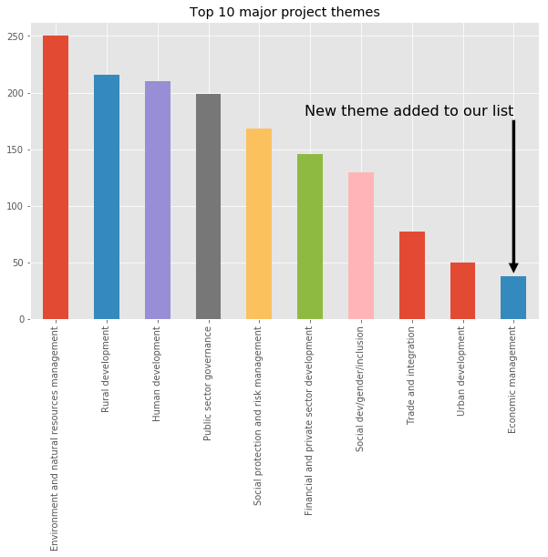

```python
# Plotting a bar graph for correct top 10 major themes

plt.figure(figsize = (10, 6))

wb_df2.name.value_counts().nlargest(10).plot(kind = 'bar')
plt.title('Top 10 major project themes')
plt.annotate('New theme added to our list', xy = (9, 40),
             xytext = (9, 180),
             arrowprops = dict(facecolor = 'black'),
             ha = 'right', size = 16);
```

Therefore, the top 10 project themes are:

1. Environment and natural resources management
2. Rural development
3. Human development
4. Public sector governance
5. Social protection and risk management
6. Financial and private sector development
7. Social dev/gender/inclusion
8. Trade and integration
9. Urban development
10. Economic management

The new, corrected dataframe is now stored in the same wb_df2.